# Buffalo bTB Testing Data Analysis

Andrew J K Conlan

10/10/2023

# Data Set

The data set consists of the results of 3 diagnostic tests for bovine Tuberculosis (bTB) for 282 animals taken from 19 groups for which there was at least one positive test result. The diagnostic threshold for SIT & SICCT was taken as $\geq 4$ mm ($\Delta B$, $\Delta B - \Delta A$) and $\geq 2$ mm for DST ($\Delta DST$).

Figure 1 below compares the apparent group prevalence in each herd based on these 3 diagnostic tests, point estimates along with naive 95% binomial confidence intervals.

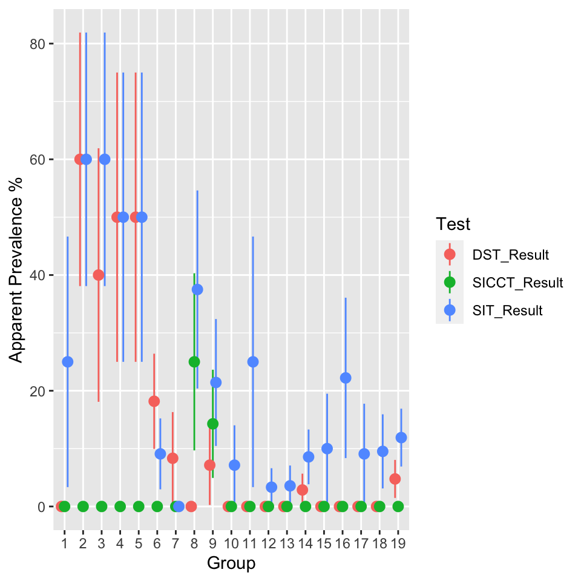

# Walter-Hui Latent Class Model

The Walter-Hui latent class model provides a theoretical framework to estimate the sensitivity and specificity of competing diagnostic tests when samples are available from at least two populations with differing prevalence (Collins and Huynh 2014; Hui and Walter 1980). A key assumption of the Walter-Hui (WH) model is that of conditional independence between tests, i.e. the probability of a test $k$ being positive for individual ($i$), $P(T_{i,k} = 1)$ only depends on the latent (true) disease status of the individual ($D \in \{0,1\}$) and not the response of the other tests. Under this assumption the (conditional) probability of a positive test result given that an animal is infected ($D=1$) or disease free ($D=0$) can then be modelled by a single parameter for each test:

$$P(T_{i,k} = 1 | D = 1) = a_{k}$$
$$P(T_{i,k} = 1 | D = 0) = b_{k}$$

and the sensitivity of test $k$ will then simply be $a_{k}$ and the specificity will be $1-b_{k}$.

Following (Collins and Huynh 2014; Dendukuri, Hadgu, and Wang 2009), and to allow for an extension to model any conditional dependence between tests, we parameterise the model using a probit ($\Phi$) link function :

$$P(T_{i,k} = 1 | D = 1) = \Phi(a_{k,1})$$
$$P(T_{i,k} = 1 | D = 0) =
\Phi(a_{k,0})$$

To ensure numerical stability we restrict the sensitivity parameters (on the probit scale) $a_{k,1}$ to the range $[-8,8]$.

A common issue with this class of models is that the likelihood can be symmetric under relabeling of the latent variable. This leads to a multi-modal posterior distribution where where two modes can provide an equivalent fit to the data corresponding to the situation where the true positive rate is greater than the false positive rate (TPR > FPR, $\Phi(a_{k,1}) > \Phi(a_{k,0})$) and the inverse where the FPR > TPR ($\Phi(a_{k,0}) > \Phi(a_{k,1})$). Given the performance of the SIT and SICCT tests in other contexts we consider the situation where the FPR > TPR to be biologically implausible and choose prior assumptions to force selection of this mode by restricting $a_{k,0}$ to the range [-8,-1] - equivalent to assuming that no tests have a specificity of $< 80%$. For this baseline model we further assume non-informative normal (0,1) distributions for $a_{k,1}, a_{k,0}$ and a beta $(1,1)$ distribution for the true within-herd prevalence (i.e. the latent or true prevalence).

The SIT and SICTT test results have an implicit dependence on each other in the sense that they are both calculated based on the magnitude of the observed reaction to bovine tuberculin. The comparison to avian tuberculin in the SICCT test is intended to raise specificity and reduce sensitivity. A biological dependence between the tests – implies - but does not guarantee that there will be a statistical association between the results of the two tests strong enough to violate the assumption of conditional independence. If the correlation between (true) infection status and the results of each test result is large compared to the correlation between the test results themselves then the conditional dependence will not affect the parameter estimates and the test results can effectively be treated as (statistically) independent. Dendukuri, Hadgu, and Wang (2009) proposed a method for testing whether the assumption of conditional dependence is satisfied by calculating the pairwise probability of agreement between each pair of diagnostic tests ($k,k'$):

$$\alpha_{k,k'} =
\frac{\sum_{i=1}^{N} T_{i,k} T_{i,k'} - (1-T_{i,k})
(1-T_{i,k'})}{N}$$

Any systematic differences between the observed ($\alpha_{k,k'}$) and expected values from the estimated model ($\alpha^{*}_{k,k'}$) would imply a violation of the assumption of conditional independence. We can use draws from the posterior predictive distribution of $\alpha^{*}_{k,k'}$ for our fitted model to form a posterior predictive p-value (Gelman et al. 2014):

$$P(\alpha^{*}_{k,k'} >
\alpha_{k,k'})$$

If the model fits well, the value of $P(\alpha^{*}_{k,k'} > \alpha_{k,k'})$ is expected to be close to $0.5$, with extreme values close to $0$ or $1$ indicating a lack of fit.

As a further exploration of this issue we suggest an alternative model to account for potential conditional dependence between the SIT and SICCT tests. We propose that the sensitivity and specificity of the two tests can be interpreted as points on a shared receiver-operator-characteristic (ROC) curve. This is equivalent to a reparameterisation of the baseline model to use an assumed functional form that links the parameters for these two tests.

Specifically, we use a normal model for the ROC curve (Irwin and Hautus 2020) which arises from assuming that the false and true positive rates for each test have equal variance $\sigma_{g}$. The parameter $\sigma_{g}$ defines the shape of the ROC curve and the relationship between sensitivity and specificity for a group of tests $g$. Using this functional form we can write the conditional probabilities of a positive result as:

$$P(T_{i,k} = 1 | D = 0) = \Phi(a_{k,0})$$
$$P(T_{i,k} = 1 | D = 1) =
\Phi(\Phi^{-1}(a_{k,0}) + i_{g} \sigma_{g})$$

Where we have two groups $g={1,2}$ with a shared parameter ($\sigma_{1}$) for the SIT and SICCT tests constraining them to lie on a shared ROC curve and a separate parameter $\sigma_{2}$ for the DST. For brevity, we will thus refer to this as the WHROC model.

For the whROC model we restrict the range of $\sigma_{g}$ to $[0,8]$ and use an indicator variable $i_g$ to choose between the default (TPR > FPR; $i_g = 1$) and alternative prior assumptions (FPR > TPR; $i_g = -1$). As well as allowing us to explicitly model the potential dependence between SIT and SICCT tests, we can also illustrate the parameter estimates that would be obtained by specifying the alternative prior (FPR > TPR;$i_g = -1$).

Again, we assume normal(0,1) priors for both $a_{k,0}$ and $\sigma_g$ and a beta(1,1) prior for the (true or latent) within-herd prevalence. For the SIT/SICCT tests, and in common with the prior assumptions for the baseline model above we set $i_{g}=1$ corresponding to the assumption that both tests have a TPR > FPR. Thus we fit a total of three models corresponding to the baseline WH model and the alternative WHROC model with the default and alternative prior assumptions:

- Model 1: Baseline WH model
- Model 2: WHROC model SIT, SICCT (Default Prior, $i_{g}=1$), DST (Default Prior, $i_{g}=1$)
- Model 3: WHROC model SIT, SICCT (Alternative Prior, $i_{g}=-1$), DST (Alternative Prior, $i_{g}=-1$)

The models were implemented using stan and estimated using Hamiltonian MCMC (Carpenter et al. 2017). Convergence was assessed through visual inspection of the chains and standard diagnostic statistics ($\hat{R}=1$ for all parameters after $4,000$ iterations for 8 chains). Convergence was assessed through visual inspection of the chains and standard diagnostic statistics ($\hat{R}=1$ for all parameters after $4,000$ iterations for 8 chains). We used leave-one-out (LOO) cross-validation (Vehtari, Gelman, and Gabry 2017) for model comparison and selection. The expected log pointwise predictive density: $\hat{elpd}$, which measures the predictive accuracy of the model when a single observation is dropped out, was estimated by Pareto smoothed importance sampling (PSIS-LOO) [https://mc-stan.org/loo]. The difference ($\Delta \hat{elpd}$) between $\hat{elpd}$ for alternative models fitted to the same data provides a measure of their relative predictive accuracy. The standard error on the difference gives a measure of uncertainty. Standard errors comparable to the magnitude of the difference ($\Delta \hat{elpd}$) suggest that the relative predictive accuracy of the two models is indistinguishable.

### Posterior estimates

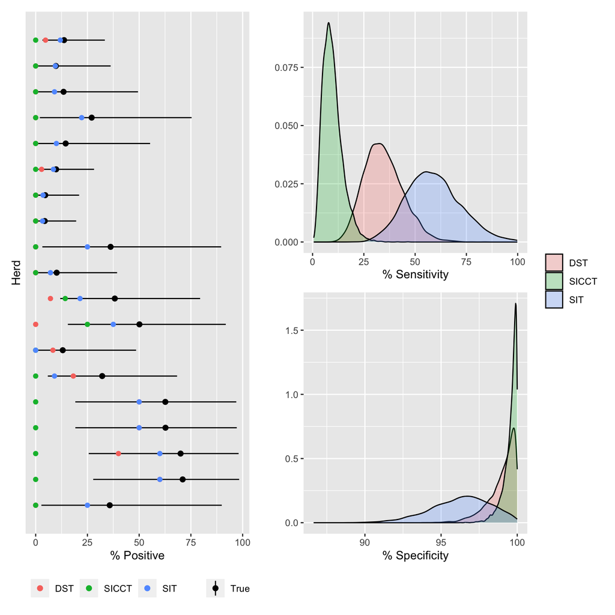

```
## # A tibble: 18 × 6
## # Groups:   .variable, t [6]
##    .variable   t     Model           m         l       u
##    <chr>       <chr> <chr>       <dbl>     <dbl>   <dbl>
##  1 sensitivity DST   WH        33.8    18.4       54.9
##  2 sensitivity DST   WHROC     25.6    13.8       44.6
##  3 sensitivity DST   WHROC Alt  0.464   0.0107     2.74
##  4 sensitivity SICCT WH         8.99    2.78      21.2
##  5 sensitivity SICCT WHROC      7.53    2.53      17.6
##  6 sensitivity SICCT WHROC Alt  0.0401  0.000639   0.422
##  7 sensitivity SIT   WH        58.2    35.3       86.8
##  8 sensitivity SIT   WHROC     43.1    26.2       66.1
##  9 sensitivity SIT   WHROC Alt  3.02    0.323      7.16
## 10 specificity DST   WH        99.3    96.6      100.
## 11 specificity DST   WHROC     98.9    96.3       99.9
## 12 specificity DST   WHROC Alt 73.0    54.9       85.4
## 13 specificity SICCT WH        99.7    98.3      100.
## 14 specificity SICCT WHROC     99.8    99.1      100.
## 15 specificity SICCT WHROC Alt 92.9    83.5       97.6
## 16 specificity SIT   WH        96.5    92.1       99.5
## 17 specificity SIT   WHROC     95.1    91.0       98.0
## 18 specificity SIT   WHROC Alt 50.9    27.7       69.3
```

### Comparison of model estimates for WH and WHROC models (default prior assumption)

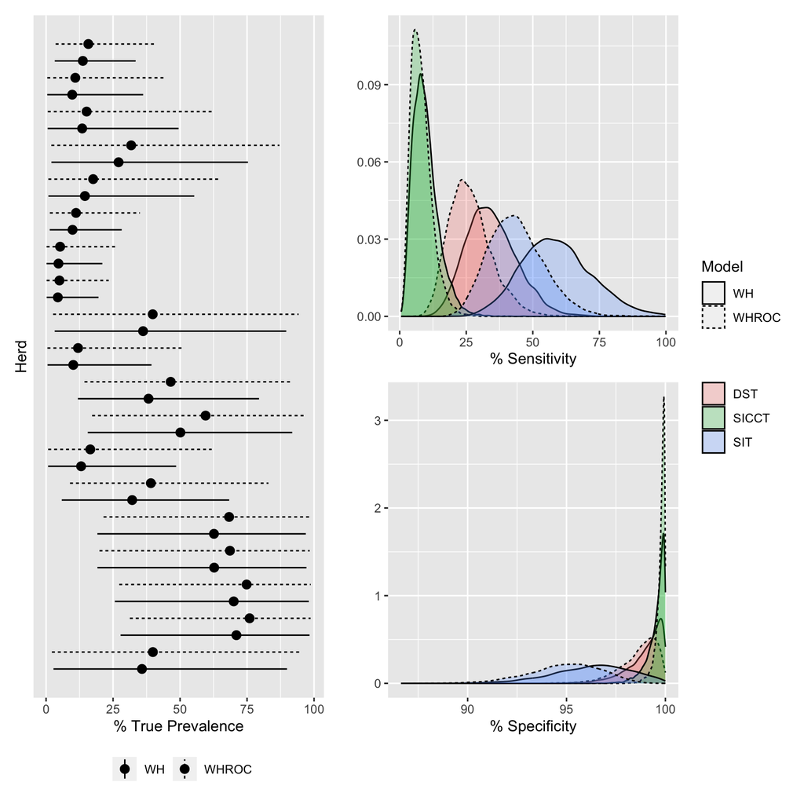

### Comparison of parameter estimates for default (TPR > FPR) and alternative (FPR > TPR) prior assumptions (whROC model)

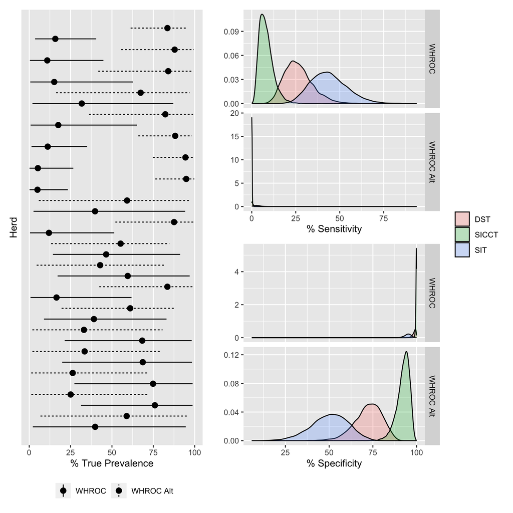

## Posterior Predictive Checks of Model Fit

Model fit was assessed through two sets of posterior predictive checks: the apparent prevalence and the pairwise probability of agreement between each pair of diagnostic tests ($k,k'$) in each group (unaffected, affected).

### Apparent Prevalance

The fitted model demonstrates an excellent agreement with the apparent prevalence across all infected and uninfected herds. All of the observed values lie within the 95% posterior predictive intervals of the estimated model.

#### WH model

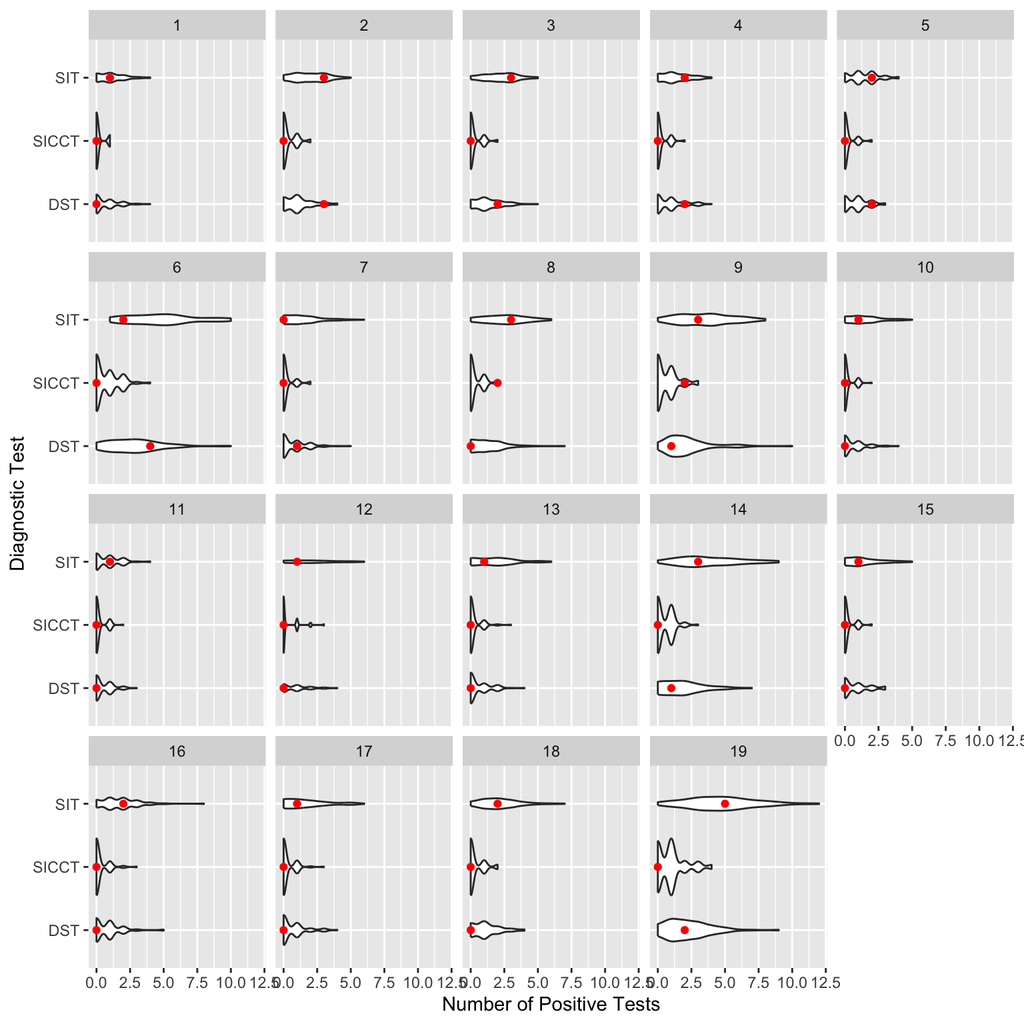

#### WH ROC model (default prior)

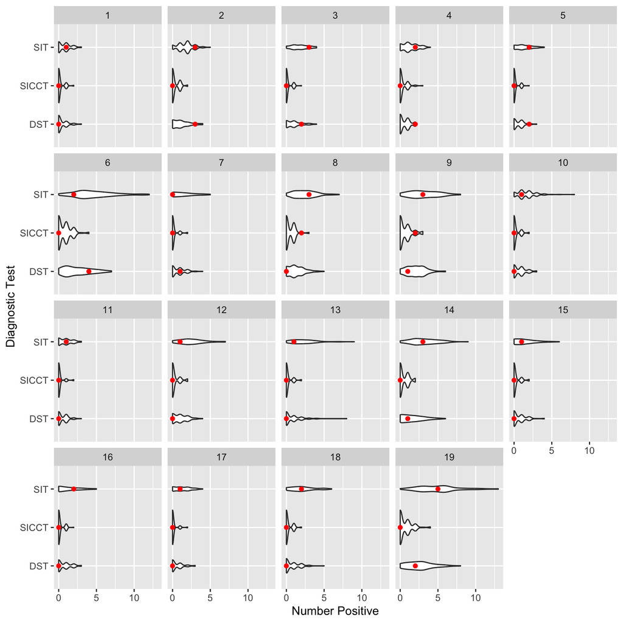

[figure not shown]

### Pairwise probability of agreement between tests

#### WH Model

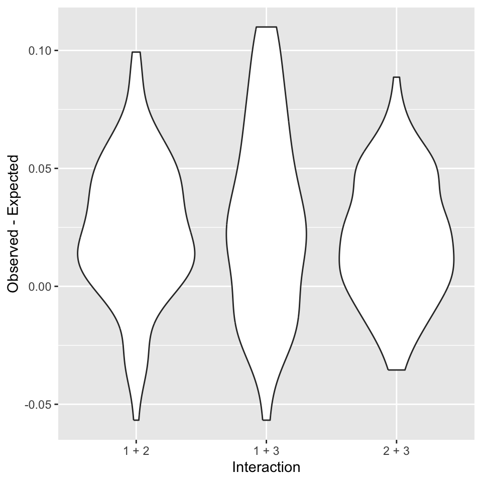

```
## # A tibble: 3 × 2
##   pair  `mean(alpha > obs_val)`
##   <chr>                   <dbl>
## 1 1 + 2                    0.8
## 2 1 + 3                    0.72
## 3 2 + 3                    0.78
```

#### ROC model (Default Priors)

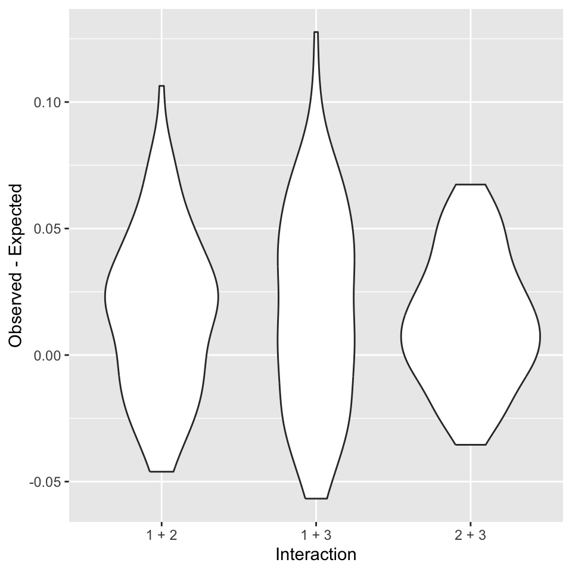

```
## # A tibble: 3 × 2
##   pair  `mean(alpha > obs_val)`
##   <chr>                   <dbl>
## 1 1 + 2                    0.66
## 2 1 + 3                    0.65
## 3 2 + 3                    0.71
```

#### ROC model (Alternative Priors)

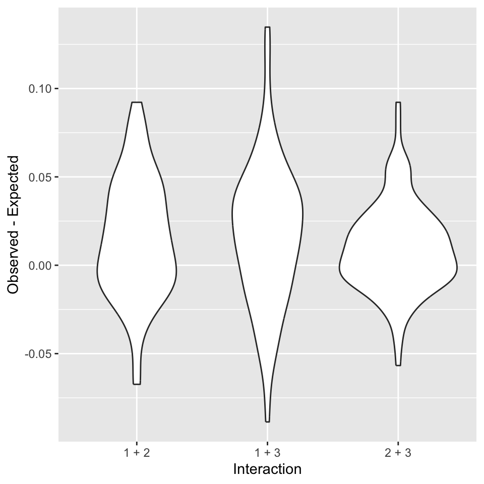

```
## # A tibble: 3 × 2
##   pair  `mean(alpha > obs_val)`
##   <chr>                   <dbl>
## 1 1 + 2                    0.61
## 2 1 + 3                    0.69
## 3 2 + 3                    0.64
```

### Leave-one-out (LOO) cross validation checks

##### WH Model

```
##
## Computed from 8000 by 282 log-likelihood matrix
##
##          Estimate   SE
## elpd_loo   -175.3 17.2
## p_loo        14.5  1.7
## looic       350.7 34.3
## ------
## Monte Carlo SE of elpd_loo is 0.1.
##
## All Pareto k estimates are good (k < 0.5).
## See help('pareto-k-diagnostic') for details.
```

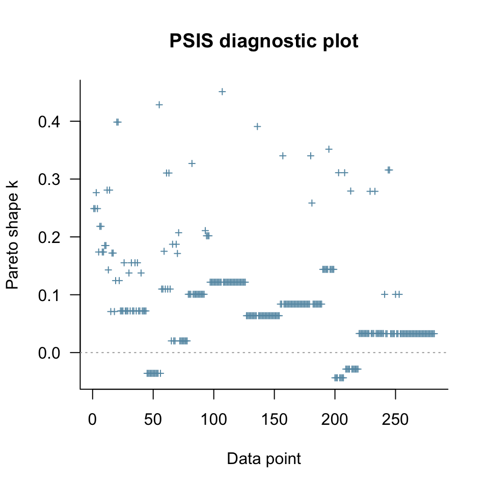

##### WHROC Model

```
##
## Computed from 8000 by 282 log-likelihood matrix
##
##          Estimate   SE
## elpd_loo   -177.0 17.5
## p_loo        12.7  1.6
## looic       354.0 35.0
## ------
## Monte Carlo SE of elpd_loo is 0.0.
##
## All Pareto k estimates are good (k < 0.5).
## See help('pareto-k-diagnostic') for details.
```

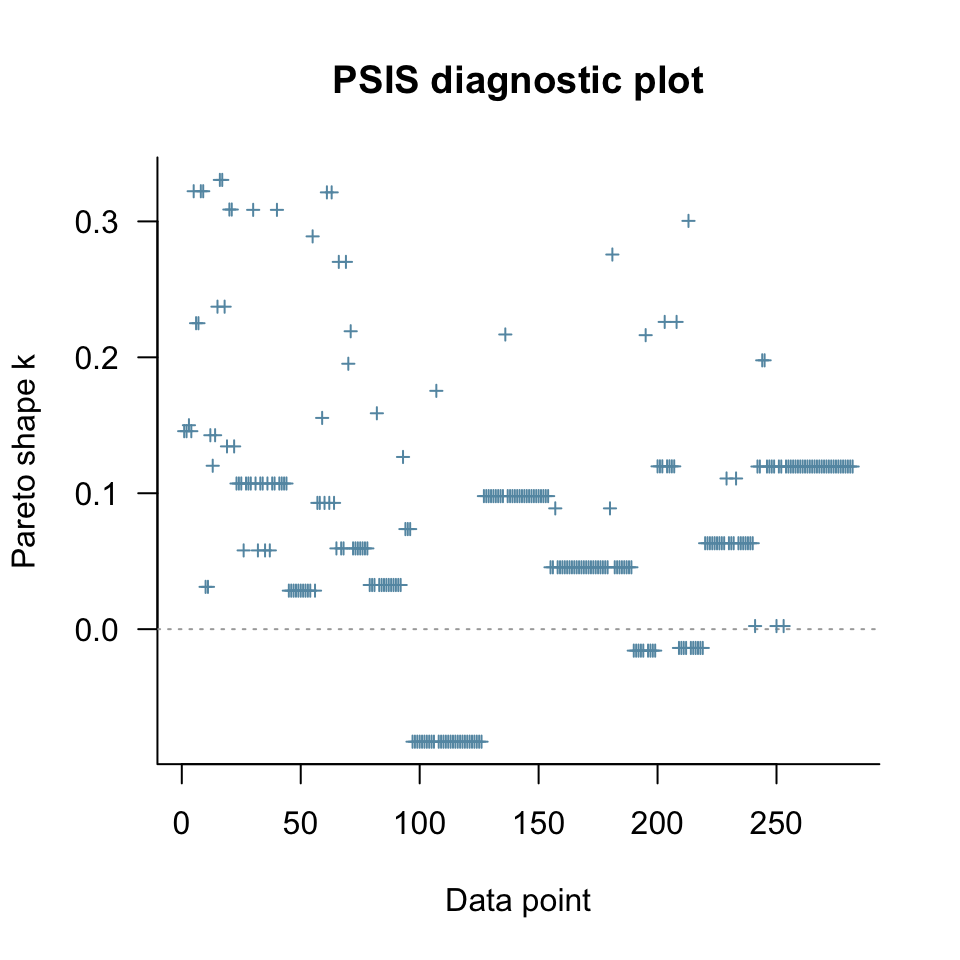

```
##
## Computed from 8000 by 282 log-likelihood matrix
##
##          Estimate   SE
## elpd_loo   -175.8 17.7
## p_loo        14.3  1.7
## looic       351.7 35.4
## ------
## Monte Carlo SE of elpd_loo is 0.1.
##
## Pareto k diagnostic values:
##                          Count Pct.    Min. n_eff
## (-Inf, 0.5]   (good)     280   99.3%   3767
##  (0.5, 0.7]   (ok)         2    0.7%   3338
##    (0.7, 1]   (bad)        0    0.0%   <NA>
##    (1, Inf)   (very bad)   0    0.0%   <NA>
##
## All Pareto k estimates are ok (k < 0.7).
## See help('pareto-k-diagnostic') for details.
```

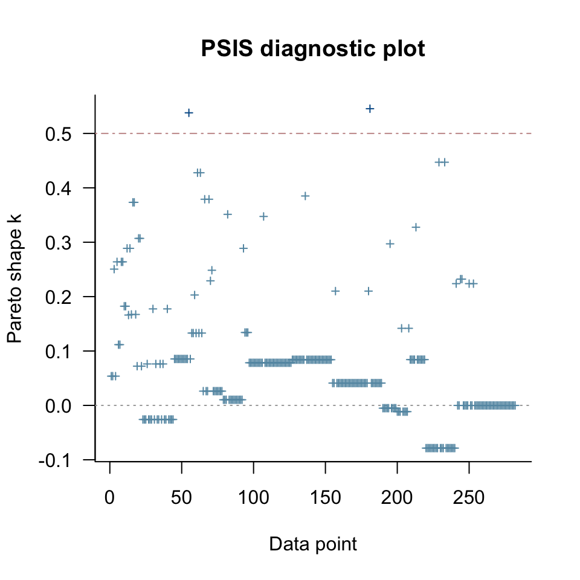

#### Model Comparison

```
##        elpd_diff se_diff
## model1  0.0       0.0
## model3 -0.5       1.2
## model2 -1.7       2.0
```

# References

Carpenter, Bob, Andrew Gelman, Matthew D. Hoffman, Daniel Lee, Ben Goodrich, Michael Betancourt, Marcus Brubaker, Jiqiang Guo, Peter Li, and Allen Riddell. 2017. “Stan: A Probabilistic Programming Language.” *Journal of Statistical Software* 76 (1): 1–32. doi:10.18637/jss.v076.i01.

Collins, John, and Minh Huynh. 2014. “Estimation of Diagnostic Test Accuracy Without Full Verification: A Review of Latent Class Methods.” *Statistics in Medicine* 33 (24): 4141–69. doi:10.1002/sim.6218.

Dendukuri, N., A. Hadgu, and L. Wang. 2009. “Modeling Conditional Dependence Between Diagnostic Tests: A Multiple Latent Variable Model.” *Statistics in Medicine* 28 (3): 441–61. doi:10.1002/sim.3470.

Gelman, Andrew, John B. Carlin, Hal S. Stern, David B. Dunson, A. Vehtari, and D B. Rubin. 2014. *Bayesian Data Analysis*. Third Edition. Chapman & Hall.

Hui, S. L., and S. D. Walter. 1980. “Estimating the Error Rates of Diagnostic Tests.” *Biometrics* 36 (1): 167–71. doi:10.2307/2530508.

Irwin, R. John, and Michael J. Hautus. 2020. “Lognormal Lorenz and Normal Receiver Operating Characteristic Curves as Mirror Images.” *Royal Society Open Science* 2 (2): 140280. Accessed September 28. doi:10.1098/rsos.140280.

Vehtari, Aki, Andrew Gelman, and Jonah Gabry. 2017. “Practical Bayesian Model Evaluation Using Leave-One-Out Cross-Validation and WAIC.” *Statistics and Computing* 27 (5): 1413–32. doi:10.1007/s11222-016-9696-4.